# Plant nutrition

## Mineral nutrition in plants

- **Plants are capable of making all necessary organic compounds from inorganic compounds and elements in the environment**
  - aka ‘autotrophic’
  - mineral: an inorganic element (e.g. inorganic ion from soil)
  - some minerals are essential and some are beneficial
- **These resources often have multiple functions in the plant**
  - metabolic, biochemical, structure, etc
  - amount required or present varies
- **Review: acquiring these resources requires and above- and belowground body plan**
  - plants are ‘environmental miners’

## What did you find: What limits plant growth and survival?

1. What resource is most limiting for plants?
2. Are there places on earth that are more nutrient limited than others?
3. What plant ecosystems (natural/managed) are nutrient limited?
4. What is the current state of nutrient limitation in global croplands?

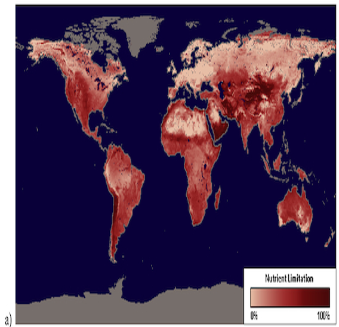

## Resources for photosynthesis

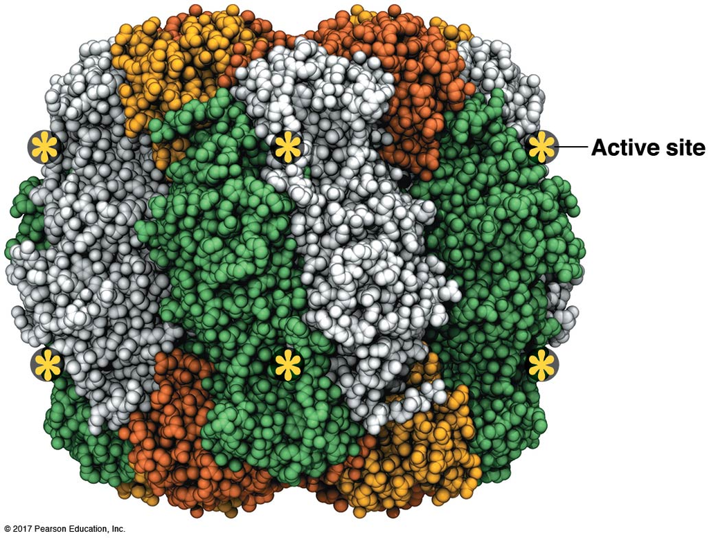

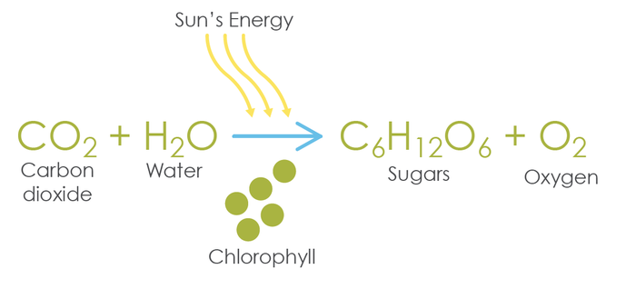

## Nutritional elements for growth

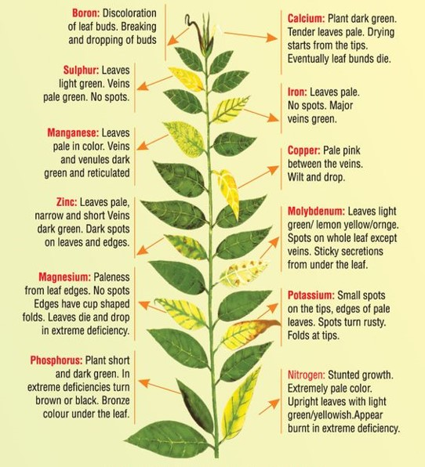

- **Carbon, Hydrogen & Oxygen**
- > 95% of biomass
- **Most have multiple functions**
- **A few are often naturally limiting**
  - why we fertilizer

## N - P - K

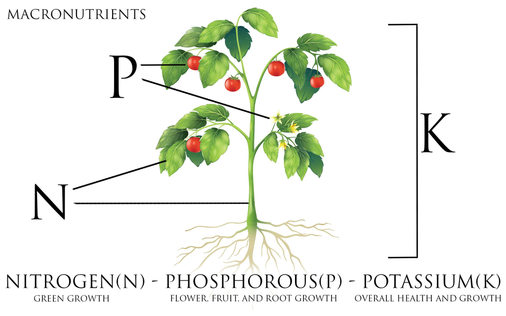

[figure not shown]

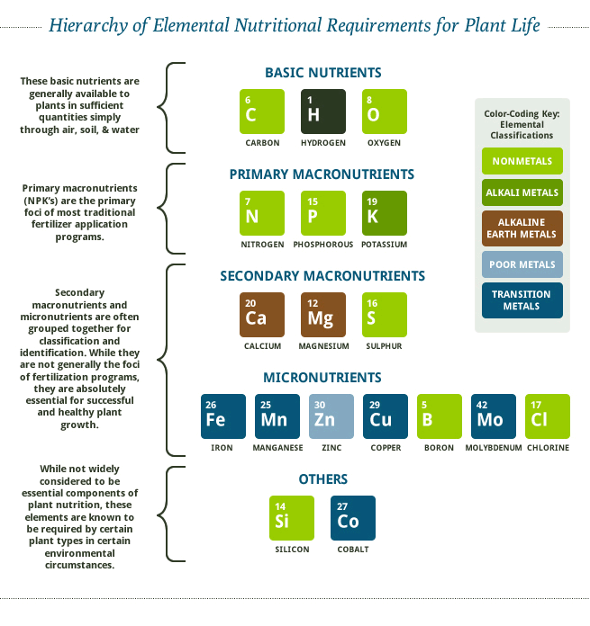

## Mineral elements come from soil

[figure not shown]

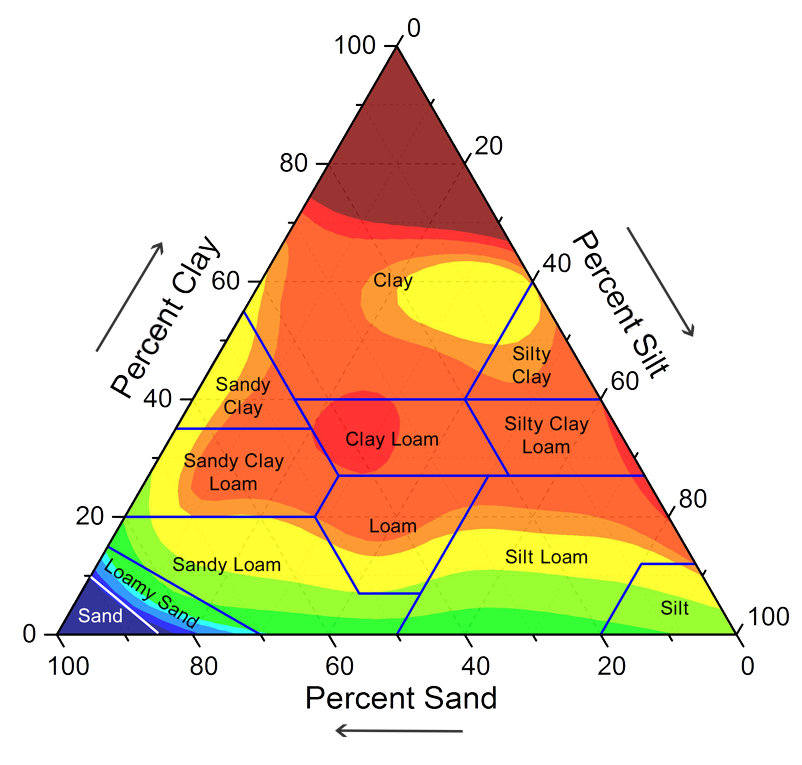

## Review: Nutrient uptake by roots

[figure not shown]

## Review: Nutrient uptake via fungi

[figure not shown]

## Nutrients may be abundant but not available: Nitrogen

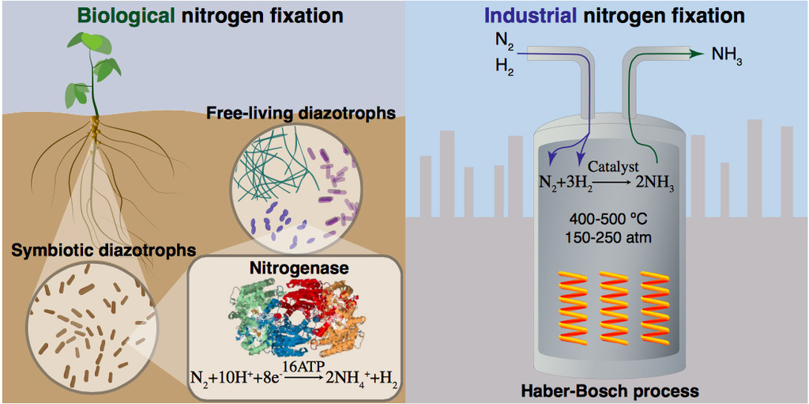

## Nutrients may be abundant but not available: Nitrogen

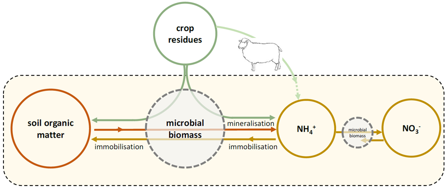

## Cool plant adaptations

[figure not shown]

## What is the most essential resource for plants?

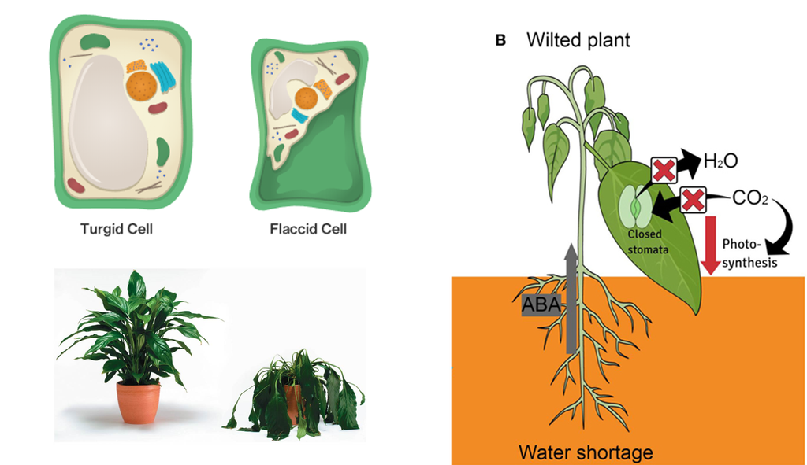

## What resource most limits plants?

- **Answer: whichever resource is the most limiting**
- **Liebig’s Law of the minimum**
  - growth is dictated not by total resources available, but by the scarcest resource
- **Adding N-P-K to a crop is useless if there is no calcium**

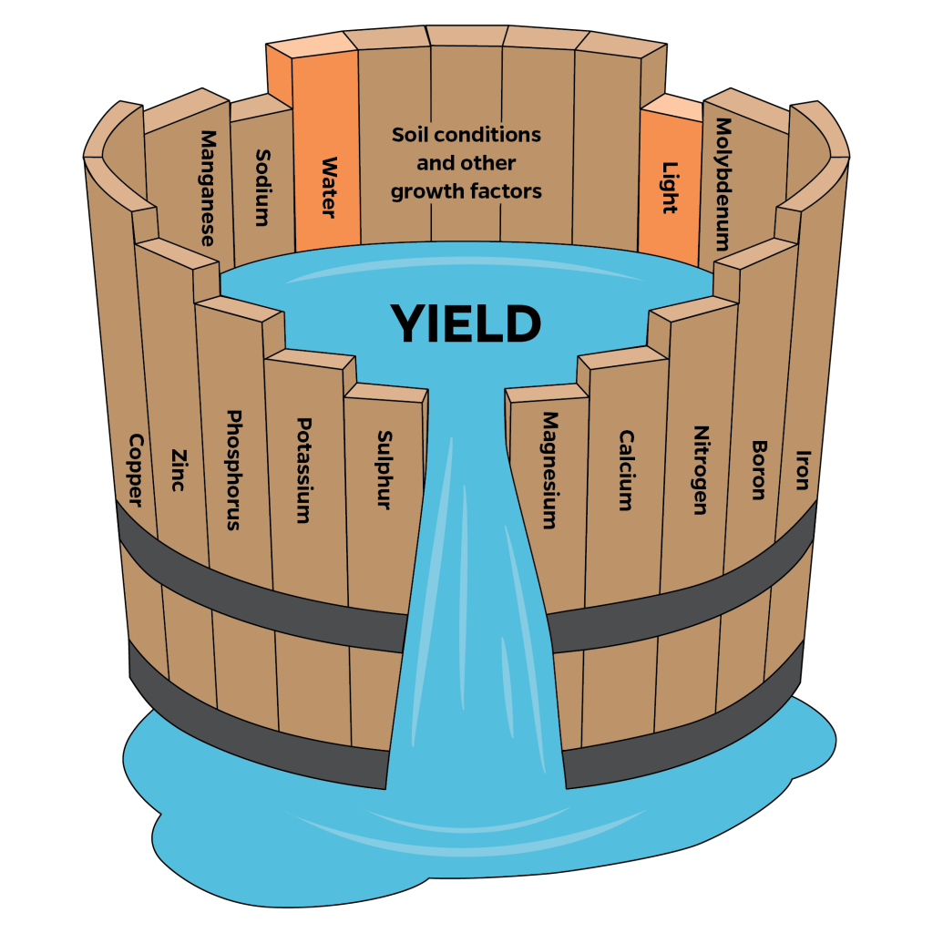

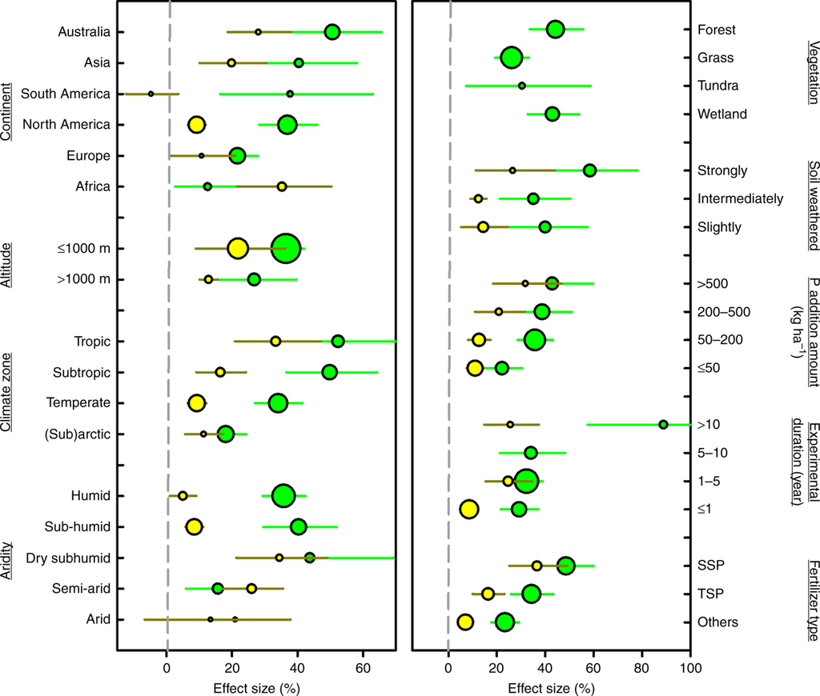

## Plant nutrient limitation in crop systems

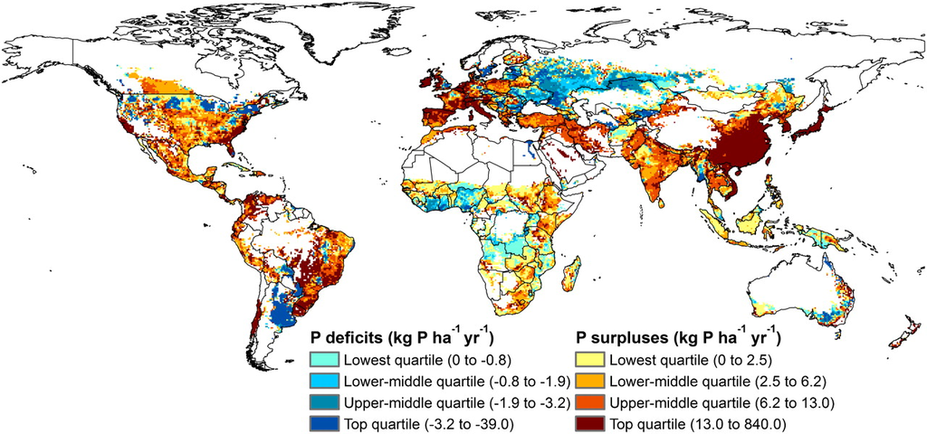